# GoBike Data Anlysis Project

## by Mohamed Abd El Motaal Mohamed

## Investigation Overview

## Dataset Overview

> In this prentation of JupytherNotebook a dataset containing data Gobike information collected from a bike renting company is explored. The dataset has a number of 183412 observations and 16 features, including information about the durations of rides, stations at which the rides is started and likewise the stations at which the rides end. In addition to data about the rideres and useres such as birthdate gender and type if subscriber or customer.

## Bike Riding Duration

> I start by looking into the duration in seconds to understand the nature of distribution of this feature. The last figure shows how that the median which is 50% of the observations lie below is approximately 8.48 minutes. this dissipates the importance of other values that extends in arange up to 600 miutes. This shows also how that large portion of the bike rideres are taking their bikes for short durations (less than 10 minutes) as will be discussed later on.

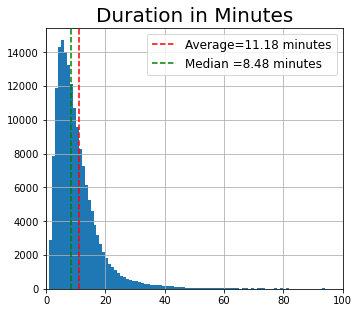

## Age and average age stage of useres

> Most of the users in all there genders and types are approximaetly of the same age stage around 35 yeas old. This can be useful for markettin and age targetting.

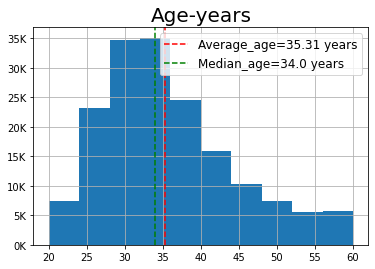

## Gender of Riders¶

> Vast majority of useres are of male gender.This can be utilized as an important item of marketing.

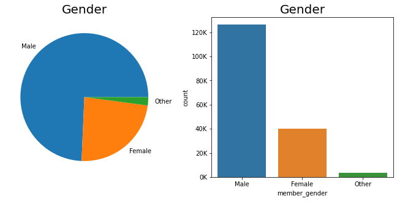

## Different Types of Users¶

> Vast majority of useres are of subscribers. very little portion are those who are customers. This means useres who are more often to use bikes are ones who have already registered with reguular usgae and payemnt. This gives us a hint that feutre study should include a survey or qustioneer about the service to get knowledge about the new customers who joined the company as subscriberes recently to measure and evaluate the performance of the service.

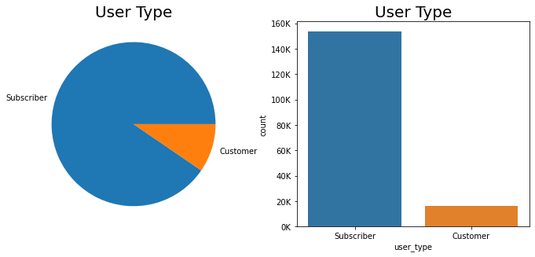

## The Most Propable Time a User Gets for a Ride¶

> In the next two figures the histograms give a hint about the existence of two peaks in the day for the starting and endings of the rides. This fact in reflected from the bimodal graphs above. in the starting hours, the two peaks are approximately at 8.0 A.M and 5:30 P.M. The numbers are similar when taking about the ending hours also. This may be read as side by side to the fact that the majority of durations are short ones to draw a picture of the whole situation. this can be read as if the users are using bikes as atransportation means to and from their distinations at the begining of the day and once more at the end of it.

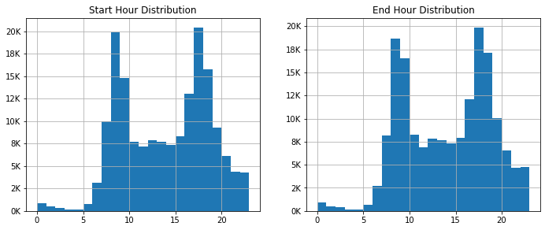

## Start and End Stations.

> An eye catching point in the above plot is that every station has approximately the same number of the bike riders who are frequently using the station in both direction i.e as origin or as distinaation.Because the points are all approximately located on a 45-degree line on the plot. Since every point represnts a station, then demand on stations is approximately equal to supply. This can be justified as the same number of useres who are leaving the station,return back at some time with same number. This supports the idea that the stations and bikes are used as a means of transportation.

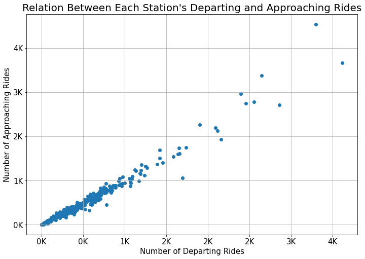

## An Emphasize on The Point

> The heat map below gives strong correlation between stations as origins and distainations. As an emphasize on the reading of the previous point plot figure.

```
[Text(0, 0.5, 'Leaving Sattion'), Text(0, 1.5, 'Returning to Station')]
```

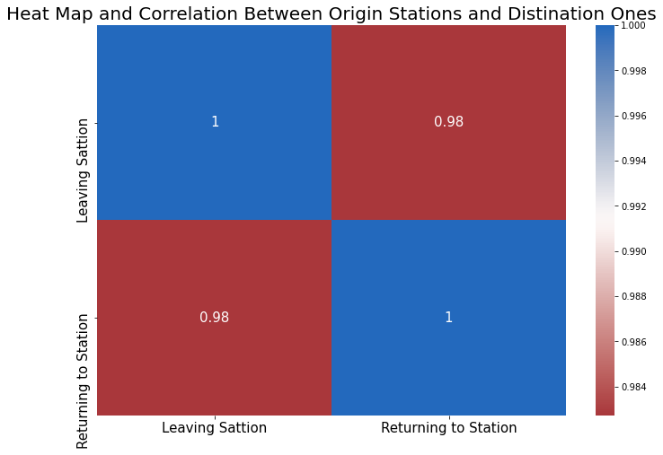

## Gender in The Focus

> Most of the users in all there genders and types are approximaetly of the same age stage around 35 yeas old. This can be useful for markettin and age targetting.

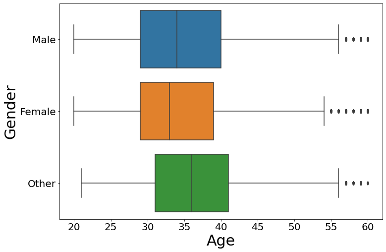

## Rush Hours Through the Day Start and End

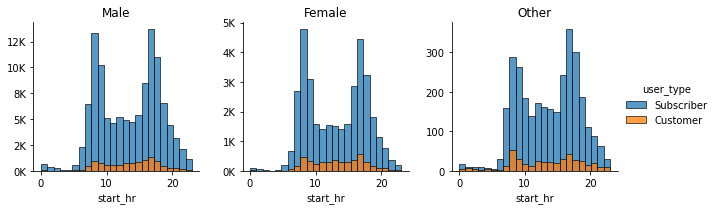

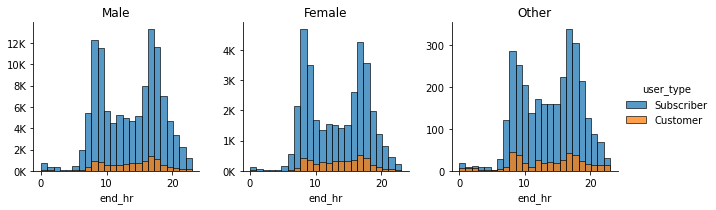

## Gender, User Type at The Start and End of The Day

> When specifically talking about male subscribers, the total riders number is much higher (more than 40 thousand users) than the female users (14 thousand) for the early hours of the day (morning period). A slight increase in customer type users is nonticed when talking female gender rather than male useres but again this goes true only for customer type users. Whereas in general other type gender has much lower portions.

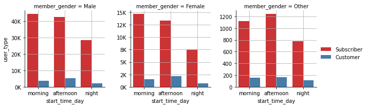

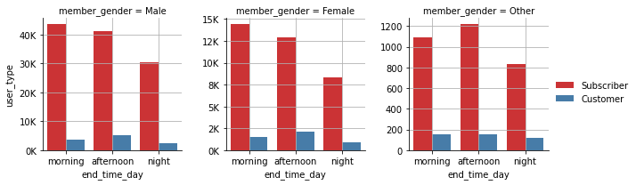